# NBA Playoff Performance Prediction (3)

### Introduction

The National Basketball Association (NBA) is the most famous and popular basketball league in the United States of America. The league is a way for athletes from all over the world to gain fame, wealth and have the glory of playing basketball in the United States. The playoffs are an important way for teams to show they are the best overall, as only 16 teams are able to make the playoffs from the regular season. In this project, we will use the stats from the regular 2024-2025 season to see how well a team performs in the post season, using predictors such as point scored, rebounds, assists, three pointers made in a game, field goal percentages and amount of steals. The top 5 players, by minutes, on each playoff team will have these stats averaged between each other to see team statistics.

```python
import requests
import pandas as pd
from nba_api.stats.static import teams
from nba_api.stats.endpoints import LeagueGameFinder, LeagueDashPlayerStats
import time

# NBA Team IDs
nba_team_ids = {t['id'] for t in teams.get_teams()}

# Pulling playoff games
gf = LeagueGameFinder(
    season_nullable   = '2024-25',
    season_type_nullable = 'Playoffs',
    league_id_nullable= '00'
)
games = gf.get_data_frames()[0]

# Grabbing Playoff teams
playoff_team_ids = set(games['TEAM_ID']) & nba_team_ids
assert len(playoff_team_ids) == 16

# Players per game stats
pergame = LeagueDashPlayerStats(
    season              = '2024-25',
    season_type_all_star       = 'Playoffs',
    per_mode_detailed   = 'PerGame'
).get_data_frames()[0]

# Players on playoff teams
pergame = pergame[pergame['TEAM_ID'].isin(playoff_team_ids)]

# Top 5 players by minutes on each team
top5_list = []
for tid in playoff_team_ids:
    top5 = (
        pergame[pergame['TEAM_ID'] == tid]
        .nlargest(5, 'MIN')[['PLAYER_ID','PLAYER_NAME','TEAM_ID','TEAM_ABBREVIATION']]
    )
    top5_list.append(top5)

df_top5 = pd.concat(top5_list, ignore_index=True)
player_ids_array = df_top5['PLAYER_ID'].to_numpy()

url = 'https://stats.nba.com/stats/playercareerstats'
headers = {
    'Host': 'stats.nba.com',
    'User-Agent': 'Mozilla/5.0 (Windows NT 10.0; Win64; x64) '
                  'AppleWebKit/537.36 (KHTML, like Gecko) '
                  'Chrome/114.0.0.0 Safari/537.36',
    'Accept': 'application/json, text/plain, */*',
    'Accept-Language': 'en-US,en;q=0.9',
    'Referer': 'https://stats.nba.com/',
    'Origin': 'https://stats.nba.com',
    'Connection': 'keep-alive',
}

all_seasons = []

for pid in player_ids_array:
    params = {
        'LeagueID': '',
        'PerMode':  'PerGame',
        'PlayerID': str(pid),
    }
    resp = requests.get(url, headers=headers, params=params, timeout=10)
    resp.raise_for_status()
    rs = resp.json()['resultSets'][0]
    df = pd.DataFrame(rs['rowSet'], columns=rs['headers'])

    # keep only 2024-25
    df_2425 = df[df['SEASON_ID'] == '2024-25'].copy()
    df_2425['PLAYER_ID'] = pid
    all_seasons.append(df_2425)

    time.sleep(0.5)

# combine players' data for 24-25
df_2425_all = pd.concat(all_seasons, ignore_index=True)
```

```python
from nba_api.stats.endpoints import LeagueStandingsV3

#24-25 regular-season records
standings = LeagueStandingsV3(
    season    = '2024-25',
    season_type = 'Regular Season',
    league_id   = '00'
).get_data_frames()[0]
```

```python
import numpy as np

# Grouping keys
group_keys = ['TEAM_ID','TEAM_ABBREVIATION']

# Search for percentage columns
pct_cols = (
    [c for c in df_2425_all.columns if c.endswith('_PCT')]
    + ['PLAYER_AGE','GP','GS','MIN']
)

# Columns to sum minues grouping keys
num_cols = df_2425_all.select_dtypes(include=np.number).columns.tolist()
sum_cols = [c for c in num_cols if c not in pct_cols + group_keys]

# Build agg dict, without group keys
agg_dict = {c: 'sum'  for c in sum_cols}
agg_dict.update({c: 'mean' for c in pct_cols})

# Filter out‘TOT’, ‘TOR’, and ‘DAL’ rows for calculation
df_team_metrics = (
    df_2425_all
      .loc[
         (df_2425_all['TEAM_ABBREVIATION'] != 'TOT') &
         (~df_2425_all['TEAM_ABBREVIATION'].isin(['TOR','DAL', 'BKN']))
      ]
      .groupby(group_keys)
      .agg(agg_dict)
      .reset_index()
)
```

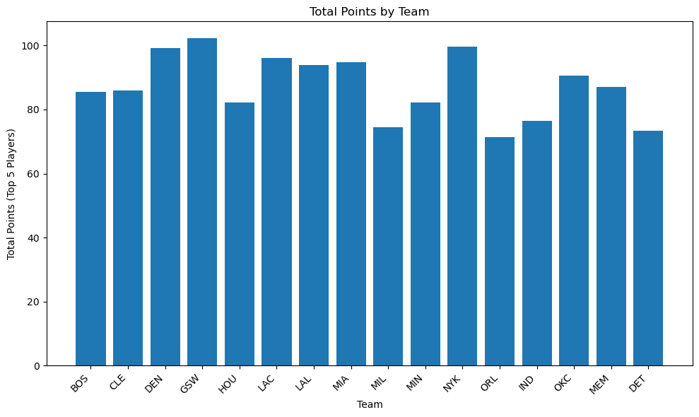

```python
import matplotlib.pyplot as plt
plt.figure(figsize=(10, 6))
plt.bar(df_team_metrics['TEAM_ABBREVIATION'], df_team_metrics['PTS'])
plt.xlabel('Team')
plt.ylabel('Total Points (Top 5 Players)')
plt.title('Total Points by Team')
plt.xticks(rotation=45, ha='right')
plt.tight_layout()
plt.show()
```

This chart compares the total playoff points scored by the top five players on each playoff team. Teams like Denver (DEN) and Golden State (GSW) show high reliance on their core players for scoring. In contrast, teams such as Detroit (DET) and Orlando (ORL) show lower outputs from their core players, which may reflect greater bench utilization, injuries, or lower overall efficiency. This visualization supports the broader question of whether teams with concentrated star performance outperform more balanced rosters in the postseason.

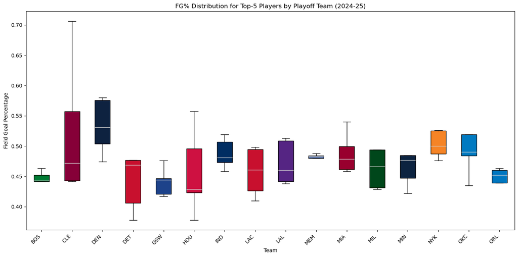

```python
# Playoff teams
playoff_teams = [
    'BOS','CLE','DEN','GSW','HOU','LAC','LAL','MIA',
    'MIL','MIN','NYK','ORL','IND','OKC','MEM','DET'
]

# Subsetting for playoff teams
df_plot = df_2425_all.loc[
    df_2425_all['TEAM_ABBREVIATION'].isin(playoff_teams)
]

# Boxplot data
teams = sorted(playoff_teams)
data = [ df_plot.loc[df_plot['TEAM_ABBREVIATION']==tm, 'FG_PCT']
         for tm in teams ]

# Team colors for boxplot
team_colors = {
    'BOS': '#007A33','CLE': '#860038','DEN': '#0E2240','GSW': '#1D428A',
    'HOU': '#CE1141','LAC': '#C8102E','LAL': '#552583','MIA': '#98002E',
    'MIL': '#00471B','MIN': '#0C2340','NYK': '#F58426','ORL': '#0077C0',
    'IND': '#002D62','OKC': '#007AC1','MEM': '#5D76A9','DET': '#C8102E'
}
colors = [team_colors.get(tm,'lightgray') for tm in teams]


plt.figure(figsize=(14,7))
bplot = plt.boxplot(data, labels=teams, patch_artist=True, showfliers=False, medianprops = {'color':'lightgray'})
for patch, color in zip(bplot['boxes'], colors):
    patch.set_facecolor(color)

plt.xticks(rotation=45, ha='right')
plt.xlabel('Team')
plt.ylabel('Field Goal Percentage')
plt.title('FG% Distribution for Top-5 Players by Playoff Team (2024-25)')
plt.tight_layout()
plt.show()
```

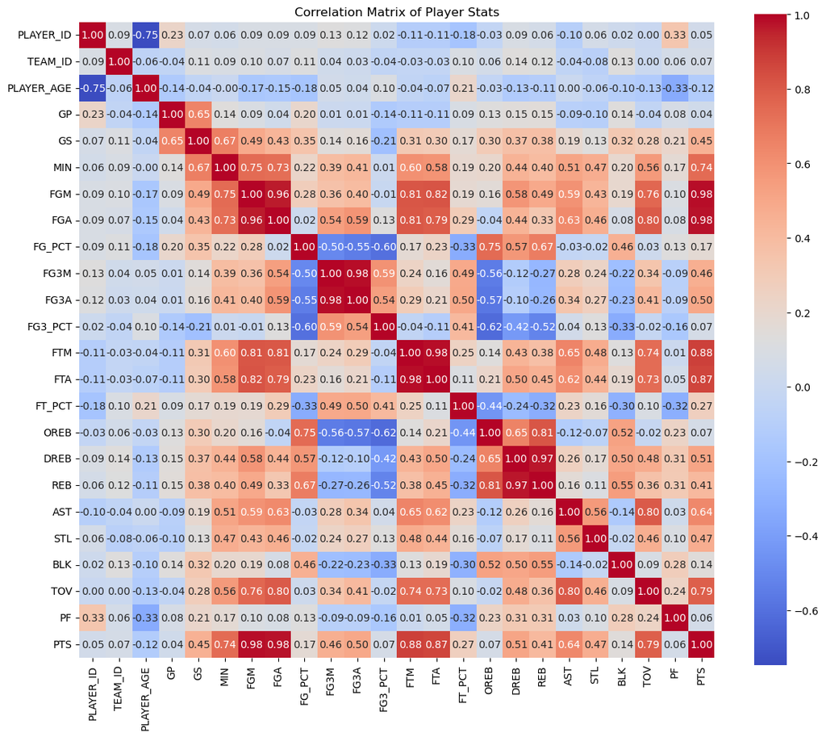

```python
import seaborn as sns
import matplotlib.pyplot as plt

# Numeric columns only
numeric_data = df_2425_all.select_dtypes(include='number')

# Correlation matrix
corr_matrix = numeric_data.corr()

# Plot heatmap
plt.figure(figsize=(12, 10))
sns.heatmap(corr_matrix, annot=True, fmt=".2f", cmap='coolwarm', square=True)
plt.title('Correlation Matrix of Player Stats')
plt.tight_layout()
plt.show()
```

Points (PTS) are highly correlated with field goals made (FGM) and minutes played (MIN), indicating that raw scoring is driven by playing time and shot volume. Points (PTS) show strong positive correlations with field goals made (FGM) and minutes played (MIN), suggesting these features may be redundant in modeling. Weak correlations between free throw percentage (FT_PCT) and other variables suggest it may offer unique predictive value. Notably, turnovers (TOV) are also strongly correlated with PTS, highlighting the tradeoff between usage and efficiency.

```python
from nba_api.stats.endpoints import leaguegamelog

gamelogs = leaguegamelog.LeagueGameLog(
    season='2024-25',
    season_type_all_star='Playoffs'
).get_data_frames()[0]
```